# Working with Dates and Times in Python

A Comprehensive, Example-Driven Reference for Time-Based Data

Robertas Gabrys

# 1 Working with Dates and Times in Python

## 1.1 A comprehensive, example-driven reference for time-based data

Dates and times appear in sales records, transactions, web events, appointments, sensor readings, financial data, staffing schedules, and many other business datasets. Before analyzing such data, we must be able to create, parse, validate, index, align, aggregate, and transform timestamps reliably.

This notebook reviews the most commonly used date/time capabilities in:

- Python's built-in `datetime` module
- `dateutil` for flexible parsing and calendar-aware arithmetic
- NumPy `datetime64` and `timedelta64`
- pandas `Timestamp`, `Timedelta`, `Period`, `DatetimeIndex`, and related tools
- Matplotlib date locators and formatters

The emphasis is on learning by example, especially when imported dates do not follow a standard format and when calendar components must be extracted to create useful features.

### 1.1.1 Learning objectives

By the end, you should be able to:

1. Distinguish dates, clock times, timestamps, durations, and periods.
2. Parse standard, nonstandard, mixed, ambiguous, and invalid date/time text.
3. Import timestamps from CSV, Excel-style values, Unix epochs, and separate columns.
4. Create regular and business-calendar date ranges.
5. Index, filter, slice, align, and join observations by time.
6. Extract calendar and clock components and design time-based features.
7. Compute lags, changes, elapsed times, and rolling summaries.
8. change frequency using `asfreq()` and `resample()` appropriately.
9. identify missing, duplicated, irregular, and misordered timestamps.
10. Work safely with time zones and daylight-saving transitions.
11. Validate a time-based dataset before using it in later analysis.

> Run the notebook from top to bottom. Then change examples, introduce errors, and observe what happens.

## 1.2 0. Setup and reproducibility

```python
from datetime import date, datetime, time, timedelta
from zoneinfo import ZoneInfo

import numpy as np
import pandas as pd
import matplotlib.pyplot as plt

pd.set_option("display.max_columns", 20)
pd.set_option("display.width", 120)
pd.set_option("display.precision", 2)

rng = np.random.default_rng(425)

print("pandas version:", pd.__version__)
print("NumPy version:", np.__version__)
```

```
pandas version: 2.2.3
NumPy version: 2.3.5
```

### 1.2.1 Core vocabulary

| Term | Meaning | pandas representation |
| --- | --- | --- |
| Timestamp | One point in time | `pd.Timestamp` |
| Duration | Elapsed time between points | `pd.Timedelta` |
| Period | A span such as “March 2026” | `pd.Period` |
| Frequency | Spacing between observations | `D`, `h`, `W`, `MS`, `QE`, etc. |
| Datetime index | Timestamps used as row labels | `pd.DatetimeIndex` |
| Time series | Values observed over ordered time | `Series`/`DataFrame` with time information |

**Important:** a timestamp and a period are not the same. `2026-03-01 10:30` is a point in time; `2026-03` may represent the entire month.

## 1.3 1. Python `date`, `time`, `datetime`, and `timedelta`

The standard library establishes the vocabulary used by every other package. A `date` answers **which calendar day**, a `time` answers **which clock time**, a `datetime` combines both, and a `timedelta` measures **elapsed duration**. Choosing the correct object prevents ambiguous calculations later.

```python
course_day = date(2026, 8, 27)
class_start = time(18, 30)
class_meeting = datetime(2026, 8, 27, 18, 30)

print(course_day, type(course_day))
print(class_start, type(class_start))
print(class_meeting, type(class_meeting))
print("Year:", class_meeting.year)
print("Month:", class_meeting.month)
print("Weekday number (Monday=0):", class_meeting.weekday())
print("Weekday name:", class_meeting.strftime("%A"))
```

```
2026-08-27 <class 'datetime.date'>
18:30:00 <class 'datetime.time'>
2026-08-27 18:30:00 <class 'datetime.datetime'>
Year: 2026
Month: 8
Weekday number (Monday=0): 3
Weekday name: Thursday
```

```python
# Durations support date arithmetic.
next_session = class_meeting + timedelta(days=7)
ninety_minutes_later = class_meeting + timedelta(minutes=90)
time_until_next = next_session - class_meeting

print("Next session:", next_session)
print("Class ends:", ninety_minutes_later)
print("Elapsed:", time_until_next)
print("Elapsed days:", time_until_next.days)
print("Elapsed seconds:", time_until_next.total_seconds())
```

```
Next session: 2026-09-03 18:30:00
Class ends: 2026-08-27 20:00:00
Elapsed: 7 days, 0:00:00
Elapsed days: 7
Elapsed seconds: 604800.0
```

### 1.3.1 Parsing strings and formatting dates

Parsing converts text to a datetime. Formatting converts a datetime to text. `%m` means month while `%M` means minute—a frequent source of errors.

```python
raw_text = "08/27/2026 06:30 PM"
parsed = datetime.strptime(raw_text, "%m/%d/%Y %I:%M %p")

print(parsed)
print(parsed.strftime("%A, %B %d, %Y at %I:%M %p"))
print(parsed.isoformat())
```

```
2026-08-27 18:30:00
Thursday, August 27, 2026 at 06:30 PM
2026-08-27T18:30:00
```

Common format codes:

| Code | Meaning | Example |
| --- | --- | --- |
| `%Y` | four-digit year | `2026` |
| `%m` | zero-padded month | `08` |
| `%d` | zero-padded day | `27` |
| `%H` | 24-hour clock | `18` |
| `%I` | 12-hour clock | `06` |
| `%M` | minute | `30` |
| `%S` | second | `00` |
| `%A` | weekday name | `Thursday` |
| `%b` / `%B` | abbreviated/full month | `Aug` / `August` |
| `%p` | AM or PM | `PM` |

Use ISO 8601 (`YYYY-MM-DD`) when you control the format. It is relatively unambiguous and sorts naturally.

## 1.4 2. `dateutil`: flexible parsing and calendar-aware arithmetic

Python's fixed `timedelta` cannot express an irregular calendar unit such as “one month.” `dateutil` fills that gap and can also interpret human-entered date strings. Its flexibility is valuable, but inference should never replace a known, documented format.

`dateutil` is commonly installed with pandas. Its parser recognizes many human-readable formats, while `relativedelta` performs calendar-aware arithmetic such as “one month later.” Flexible inference is convenient, but ambiguous numeric dates still require an explicit rule.

```python
from dateutil import parser
from dateutil.relativedelta import relativedelta, FR

print(parser.parse("March 15, 2026"))
print(parser.parse("15 March 2026 at 2:30 PM"))
print(parser.parse("15/03/2026", dayfirst=True))

month_end = datetime(2026, 1, 31)
print("30 fixed days later:", month_end + timedelta(days=30))
print("1 calendar month later:", month_end + relativedelta(months=1))
print("Next Friday:", month_end + relativedelta(weekday=FR(1)))
```

```
2026-03-15 00:00:00
2026-03-15 14:30:00
2026-03-15 00:00:00
30 fixed days later: 2026-03-02 00:00:00
1 calendar month later: 2026-02-28 00:00:00
Next Friday: 2026-02-06 00:00:00
```

Use explicit formats for repeatable structured data. Reserve flexible parsing for genuinely mixed human-entered text, and always inspect ambiguous cases.

## 1.5 3. NumPy `datetime64` and `timedelta64`

NumPy represents dates as numeric counts from an origin using a declared resolution. You rarely need to construct these arrays directly, but recognizing `datetime64[ns]`, `datetime64[D]`, and `NaT` makes pandas dtypes and error messages much easier to understand.

NumPy provides compact vectorized date/time arrays. pandas builds on NumPy's temporal ideas, so these dtypes commonly appear when inspecting imported or transformed data.

```python
np_dates = np.array(["2026-01-01", "2026-01-08", "2026-01-15"], dtype="datetime64[D]")

print("Dates:", np_dates)
print("Differences:", np.diff(np_dates))
print("Add three days:", np_dates + np.timedelta64(3, "D"))
print("Hourly resolution:", np_dates.astype("datetime64[h]"))
print("Missing NumPy date:", np.datetime64("NaT"))
```

```
Dates: ['2026-01-01' '2026-01-08' '2026-01-15']
Differences: [7 7]
Add three days: ['2026-01-04' '2026-01-11' '2026-01-18']
Hourly resolution: ['2026-01-01T00' '2026-01-08T00' '2026-01-15T00']
Missing NumPy date: NaT
```

The unit in brackets matters: `datetime64[D]` uses day resolution, whereas `datetime64[ns]` uses nanosecond resolution. pandas normally provides a friendlier interface for business data.

## 1.6 4. pandas temporal objects

pandas supplies the main tools used with tabular time-based data. `Timestamp` represents a point, `Timedelta` represents elapsed time, and `Period` represents a labeled span such as a month or quarter. `pd.to_datetime()` converts imported values into these usable temporal representations.

```python
ts = pd.Timestamp("2026-08-27 18:30")
duration = pd.Timedelta("1 day 2 hours 15 minutes")
month = pd.Period("2026-08", freq="M")

print(ts, type(ts))
print(duration, type(duration))
print(month, type(month))
print("Timestamp + duration:", ts + duration)
print("Next monthly period:", month + 1)
print("Month begins:", month.start_time)
print("Month ends:", month.end_time)
```

```
2026-08-27 18:30:00 <class 'pandas._libs.tslibs.timestamps.Timestamp'>
1 days 02:15:00 <class 'pandas._libs.tslibs.timedeltas.Timedelta'>
2026-08 <class 'pandas._libs.tslibs.period.Period'>
Timestamp + duration: 2026-08-28 20:45:00
Next monthly period: 2026-09
Month begins: 2026-08-01 00:00:00
Month ends: 2026-08-31 23:59:59.999999999
```

```python
# pd.to_datetime handles scalars, lists, Series, and many common formats.
examples = pd.Series(["2026-08-01", "08/15/2026", "August 27, 2026", "not recorded"])
parsed_examples = pd.to_datetime(examples, format="mixed", errors="coerce")

pd.DataFrame({"raw": examples, "parsed": parsed_examples})
```

|  | raw | parsed |
| --- | --- | --- |
| 0 | 2026-08-01 | 2026-08-01 |
| 1 | 08/15/2026 | 2026-08-15 |
| 2 | August 27, 2026 | 2026-08-27 |
| 3 | not recorded | NaT |

`errors="coerce"` converts invalid values to `NaT` (“Not a Time”), making bad records easy to identify. In production, do not silently discard them—inspect and document them.

```python
bad_rows = examples[parsed_examples.isna()]
print("Values that could not be parsed:")
print(bad_rows)
```

```
Values that could not be parsed:
3    not recorded
dtype: object
```

### 1.6.1 Ambiguous numeric dates: a serious data-quality risk

> **Interpretation:** both conversions succeed, but they produce different dates. A parser cannot know the source convention from these values alone. Successful parsing therefore does **not** prove correct parsing.

```python
ambiguous = pd.Series(["01/02/2026", "03/04/2026"])

comparison = pd.DataFrame({
    "raw": ambiguous,
    "month_first": pd.to_datetime(ambiguous, format="%m/%d/%Y"),
    "day_first": pd.to_datetime(ambiguous, format="%d/%m/%Y")
})
comparison
```

|  | raw | month_first | day_first |
| --- | --- | --- | --- |
| 0 | 01/02/2026 | 2026-01-02 | 2026-02-01 |
| 1 | 03/04/2026 | 2026-03-04 | 2026-04-03 |

Always specify the known format when dates are ambiguous. Successful parsing does **not** guarantee correct parsing.

## 1.7 5. Creating date ranges and understanding frequency

A regular date range defines the expected time grid. The frequency is not merely display formatting: it determines which timestamps exist, where periods begin or end, and how later alignment and aggregation behave.

```python
daily = pd.date_range("2026-01-01", periods=7, freq="D")
business_days = pd.date_range("2026-01-01", periods=7, freq="B")
month_starts = pd.date_range("2026-01-01", periods=6, freq="MS")
month_ends = pd.date_range("2026-01-01", periods=6, freq="ME")

print("Daily:", daily.tolist())
print("Business days:", business_days.tolist())
print("Month starts:", month_starts.tolist())
print("Month ends:", month_ends.tolist())
```

```
Daily: [Timestamp('2026-01-01 00:00:00'), Timestamp('2026-01-02 00:00:00'), Timestamp('2026-01-03 00:00:00'), Timestamp('2026-01-04 00:00:00'), Timestamp('2026-01-05 00:00:00'), Timestamp('2026-01-06 00:00:00'), Timestamp('2026-01-07 00:00:00')]
Business days: [Timestamp('2026-01-01 00:00:00'), Timestamp('2026-01-02 00:00:00'), Timestamp('2026-01-05 00:00:00'), Timestamp('2026-01-06 00:00:00'), Timestamp('2026-01-07 00:00:00'), Timestamp('2026-01-08 00:00:00'), Timestamp('2026-01-09 00:00:00')]
Month starts: [Timestamp('2026-01-01 00:00:00'), Timestamp('2026-02-01 00:00:00'), Timestamp('2026-03-01 00:00:00'), Timestamp('2026-04-01 00:00:00'), Timestamp('2026-05-01 00:00:00'), Timestamp('2026-06-01 00:00:00')]
Month ends: [Timestamp('2026-01-31 00:00:00'), Timestamp('2026-02-28 00:00:00'), Timestamp('2026-03-31 00:00:00'), Timestamp('2026-04-30 00:00:00'), Timestamp('2026-05-31 00:00:00'), Timestamp('2026-06-30 00:00:00')]
```

Frequently used offset aliases:

| Alias | Frequency |
| --- | --- |
| `min`, `h`, `D` | minute, hour, calendar day |
| `B` | business day (weekday calendar, not a full holiday calendar) |
| `W-MON` | weekly, anchored on Monday |
| `MS`, `ME` | month start, month end |
| `QS`, `QE` | quarter start, quarter end |
| `YS`, `YE` | year start, year end |

Anchoring matters: weekly and quarterly values can refer to different boundary dates even when they summarize the same conceptual period.

```python
# Inclusive endpoints can be controlled explicitly.
print(pd.date_range("2026-01-01", "2026-01-05", inclusive="both"))
print(pd.date_range("2026-01-01", "2026-01-05", inclusive="left"))
```

```
DatetimeIndex(['2026-01-01', '2026-01-02', '2026-01-03', '2026-01-04', '2026-01-05'], dtype='datetime64[ns]', freq='D')
DatetimeIndex(['2026-01-01', '2026-01-02', '2026-01-03', '2026-01-04'], dtype='datetime64[ns]', freq='D')
```

```python
# Custom business calendars can account for selected holidays.
from pandas.tseries.offsets import CustomBusinessDay

holidays = ["2026-01-01", "2026-01-19"]
usc_business_day = CustomBusinessDay(holidays=holidays)
pd.date_range("2026-01-01", periods=12, freq=usc_business_day)
```

```
DatetimeIndex(['2026-01-02', '2026-01-05', '2026-01-06', '2026-01-07', '2026-01-08', '2026-01-09', '2026-01-12',
               '2026-01-13', '2026-01-14', '2026-01-15', '2026-01-16', '2026-01-20'],
              dtype='datetime64[ns]', freq='C')
```

### 1.7.1 Additional sequence constructors

```python
print("Business date range:")
display(pd.bdate_range("2026-01-01", periods=6))

print("Period range:")
display(pd.period_range("2026-01", periods=6, freq="M"))

print("Timedelta range:")
display(pd.timedelta_range(start="0h", periods=5, freq="6h"))
```

```
Business date range:
Period range:
Timedelta range:
```

```
DatetimeIndex(['2026-01-01', '2026-01-02', '2026-01-05', '2026-01-06', '2026-01-07', '2026-01-08'], dtype='datetime64[ns]', freq='B')
```

```
PeriodIndex(['2026-01', '2026-02', '2026-03', '2026-04', '2026-05', '2026-06'], dtype='period[M]')
```

```
TimedeltaIndex(['0 days 00:00:00', '0 days 06:00:00', '0 days 12:00:00', '0 days 18:00:00', '1 days 00:00:00'], dtype='timedelta64[ns]', freq='6h')
```

`date_range()` creates timestamps, `period_range()` creates labeled spans, and `timedelta_range()` creates durations.

## 1.8 6. Build a realistic daily sales time series

The remaining examples use a reproducible business dataset containing daily sales, advertising spending, a promotion period, a weekly pattern, and random variation. One consistent dataset makes it easier to see how date/time operations change the same information.

```python
dates = pd.date_range("2026-01-01", periods=180, freq="D")
t = np.arange(len(dates))

trend = 0.35 * t
weekly = 18 * np.sin(2 * np.pi * t / 7)
promotion = ((dates >= "2026-03-10") & (dates <= "2026-03-16")) * 45
noise = rng.normal(0, 8, len(dates))

sales = pd.DataFrame({
    "date": dates,
    "sales": np.round(220 + trend + weekly + promotion + noise, 2),
    "ad_spend": np.round(rng.uniform(800, 1600, len(dates)), 2),
    "promotion": promotion.astype(bool)
})

sales.head()
```

|  | date | sales | ad_spend | promotion |
| --- | --- | --- | --- | --- |
| 0 | 2026-01-01 | 234.07 | 999.16 | False |
| 1 | 2026-01-02 | 229.63 | 1466.56 | False |
| 2 | 2026-01-03 | 244.57 | 1412.57 | False |
| 3 | 2026-01-04 | 222.07 | 992.30 | False |
| 4 | 2026-01-05 | 204.96 | 1003.56 | False |

```python
print(sales.dtypes)
print("Date range:", sales["date"].min(), "to", sales["date"].max())
print("Rows:", len(sales))
```

```
date         datetime64[ns]
sales               float64
ad_spend            float64
promotion              bool
dtype: object
Date range: 2026-01-01 00:00:00 to 2026-06-29 00:00:00
Rows: 180
```

### 1.8.1 The `.dt` accessor extracts vectorized calendar features

```python
sales["year"] = sales["date"].dt.year
sales["month"] = sales["date"].dt.month
sales["month_name"] = sales["date"].dt.month_name()
sales["quarter"] = sales["date"].dt.quarter
sales["day_of_week"] = sales["date"].dt.dayofweek
sales["day_name"] = sales["date"].dt.day_name()
sales["is_weekend"] = sales["day_of_week"].isin([5, 6])
sales["iso_week"] = sales["date"].dt.isocalendar().week.astype(int)

sales[["date", "year", "month_name", "quarter", "day_name", "is_weekend", "iso_week"]].head(10)
```

|  | date | year | month_name | quarter | day_name | is_weekend | iso_week |
| --- | --- | --- | --- | --- | --- | --- | --- |
| 0 | 2026-01-01 | 2026 | January | 1 | Thursday | False | 1 |
| 1 | 2026-01-02 | 2026 | January | 1 | Friday | False | 1 |
| 2 | 2026-01-03 | 2026 | January | 1 | Saturday | True | 1 |
| 3 | 2026-01-04 | 2026 | January | 1 | Sunday | True | 1 |
| 4 | 2026-01-05 | 2026 | January | 1 | Monday | False | 2 |
| 5 | 2026-01-06 | 2026 | January | 1 | Tuesday | False | 2 |
| 6 | 2026-01-07 | 2026 | January | 1 | Wednesday | False | 2 |
| 7 | 2026-01-08 | 2026 | January | 1 | Thursday | False | 2 |
| 8 | 2026-01-09 | 2026 | January | 1 | Friday | False | 2 |
| 9 | 2026-01-10 | 2026 | January | 1 | Saturday | True | 2 |

Use vectorized `.dt` operations instead of row-by-row loops. They are usually clearer and faster.

### 1.8.2 Additional calendar and clock features

```python
feature_catalog = pd.DataFrame({
    "date": sales["date"],
    "day": sales["date"].dt.day,
    "day_of_year": sales["date"].dt.dayofyear,
    "days_in_month": sales["date"].dt.days_in_month,
    "is_month_start": sales["date"].dt.is_month_start,
    "is_month_end": sales["date"].dt.is_month_end,
    "is_quarter_end": sales["date"].dt.is_quarter_end,
    "is_leap_year": sales["date"].dt.is_leap_year,
})
feature_catalog.head()
```

|  | date | day | day_of_year | days_in_month | is_month_start | is_month_end | is_quarter_end | is_leap_year |
| --- | --- | --- | --- | --- | --- | --- | --- | --- |
| 0 | 2026-01-01 | 1 | 1 | 31 | True | False | False | False |
| 1 | 2026-01-02 | 2 | 2 | 31 | False | False | False | False |
| 2 | 2026-01-03 | 3 | 3 | 31 | False | False | False | False |
| 3 | 2026-01-04 | 4 | 4 | 31 | False | False | False | False |
| 4 | 2026-01-05 | 5 | 5 | 31 | False | False | False | False |

```python
# Cyclical encodings keep Sunday and Monday close to each other numerically.
sales["dow_sin"] = np.sin(2 * np.pi * sales["day_of_week"] / 7)
sales["dow_cos"] = np.cos(2 * np.pi * sales["day_of_week"] / 7)

sales[["date", "day_name", "day_of_week", "dow_sin", "dow_cos"]].head(8)
```

|  | date | day_name | day_of_week | dow_sin | dow_cos |
| --- | --- | --- | --- | --- | --- |
| 0 | 2026-01-01 | Thursday | 3 | 0.43 | -0.90 |
| 1 | 2026-01-02 | Friday | 4 | -0.43 | -0.90 |
| 2 | 2026-01-03 | Saturday | 5 | -0.97 | -0.22 |
| 3 | 2026-01-04 | Sunday | 6 | -0.78 | 0.62 |
| 4 | 2026-01-05 | Monday | 0 | 0.00 | 1.00 |
| 5 | 2026-01-06 | Tuesday | 1 | 0.78 | 0.62 |
| 6 | 2026-01-07 | Wednesday | 2 | 0.97 | -0.22 |
| 7 | 2026-01-08 | Thursday | 3 | 0.43 | -0.90 |

Simple integer features such as Monday = 0 and Sunday = 6 incorrectly make Sunday appear far from Monday. Sine/cosine encodings preserve the circular structure of weekdays, months, hours, and similar cycles.

### 1.8.3 Illustration: weekdays form a cycle, not a straight line

Integer coding places Monday at 0 and Sunday at 6, making adjacent days appear far apart. Sine and cosine coordinates place the seven days around a circle, preserving their calendar adjacency.

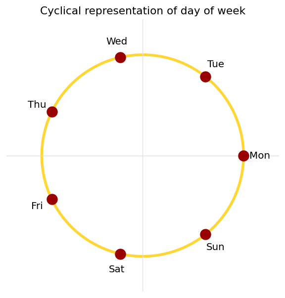

```python
weekday_names = ["Mon", "Tue", "Wed", "Thu", "Fri", "Sat", "Sun"]
weekday_number = np.arange(7)
angles = 2 * np.pi * weekday_number / 7

fig, ax = plt.subplots(figsize=(5.5, 5.5))
ax.scatter(np.cos(angles), np.sin(angles), s=130, color="#990000", zorder=3)
for name, x, y in zip(weekday_names, np.cos(angles), np.sin(angles)):
    ax.text(1.16 * x, 1.16 * y, name, ha="center", va="center", fontsize=11)
circle = plt.Circle((0, 0), 1, fill=False, color="#FFCC00", linewidth=3, alpha=.8)
ax.add_patch(circle)
ax.axhline(0, color="0.88", linewidth=.8)
ax.axvline(0, color="0.88", linewidth=.8)
ax.set(xlim=(-1.35, 1.35), ylim=(-1.35, 1.35), title="Cyclical representation of day of week")
ax.set_aspect("equal")
ax.axis("off")
plt.show()
```

The two coordinates become reusable columns: `sin(2π·day/7)` and `cos(2π·day/7)`. The same idea applies to hour of day, month of year, and other repeating calendar components.

## 1.9 7. Using a `DatetimeIndex`

A `DatetimeIndex` turns timestamps into row labels. This enables partial-date slicing, recurring clock-time selection, time-aware rolling windows, and resampling. Before relying on it, verify that it is sorted and that duplicate timestamps have a documented meaning.

```python
ts_sales = sales.set_index("date").sort_index()

print(type(ts_sales.index))
print("Monotonic:", ts_sales.index.is_monotonic_increasing)
print("Unique:", ts_sales.index.is_unique)
print("Stored frequency:", ts_sales.index.freq)
ts_sales.head()
```

```
<class 'pandas.core.indexes.datetimes.DatetimeIndex'>
Monotonic: True
Unique: True
Stored frequency: None
```

| date | sales | ad_spend | promotion | year | month | month_name | quarter | day_of_week | day_name | is_weekend | iso_week | dow_sin | dow_cos |
| --- | --- | --- | --- | --- | --- | --- | --- | --- | --- | --- | --- | --- | --- |
| 2026-01-01 | 234.07 | 999.16 | False | 2026 | 1 | January | 1 | 3 | Thursday | False | 1 | 0.43 | -0.90 |
| 2026-01-02 | 229.63 | 1466.56 | False | 2026 | 1 | January | 1 | 4 | Friday | False | 1 | -0.43 | -0.90 |
| 2026-01-03 | 244.57 | 1412.57 | False | 2026 | 1 | January | 1 | 5 | Saturday | True | 1 | -0.97 | -0.22 |
| 2026-01-04 | 222.07 | 992.30 | False | 2026 | 1 | January | 1 | 6 | Sunday | True | 1 | -0.78 | 0.62 |
| 2026-01-05 | 204.96 | 1003.56 | False | 2026 | 1 | January | 1 | 0 | Monday | False | 2 | 0.00 | 1.00 |

```python
# Select a date, a slice, or rows matching a calendar condition.
one_day = ts_sales.loc["2026-02-14"]
one_week = ts_sales.loc["2026-02-09":"2026-02-15"]
march = ts_sales.loc["2026-03"]
mondays = ts_sales[ts_sales.index.dayofweek == 0]

print("One day sales:", one_day["sales"])
print("Rows in selected week:", len(one_week))
print("Rows in March:", len(march))
print("First three Mondays:")
display(mondays[["sales"]].head(3))
```

```
One day sales: 257.24
Rows in selected week: 7
Rows in March: 31
First three Mondays:
```

| date | sales |
| --- | --- |
| 2026-01-05 | 204.96 |
| 2026-01-12 | 226.34 |
| 2026-01-19 | 222.01 |

Date slicing is inclusive at both ends in this example. With high-frequency timestamps, explicit half-open intervals are often safer.

```python
# Half-open filtering: include start, exclude end.
start = pd.Timestamp("2026-03-01")
end = pd.Timestamp("2026-04-01")
march_explicit = ts_sales[(ts_sales.index >= start) & (ts_sales.index < end)]
len(march_explicit)
```

```
31
```

### 1.9.1 Intraday selection with `at_time()` and `between_time()`

```python
hourly_index = pd.date_range("2026-02-01", periods=72, freq="h")
hourly_activity = pd.Series(rng.integers(20, 80, len(hourly_index)), index=hourly_index, name="events")

display(hourly_activity.at_time("09:00"))
display(hourly_activity.between_time("09:00", "17:00").head())
display(hourly_activity.truncate(before="2026-02-02 08:00", after="2026-02-02 12:00"))
```

|  | events |
| --- | --- |
| 2026-02-01 09:00:00 | 61 |
| 2026-02-02 09:00:00 | 45 |
| 2026-02-03 09:00:00 | 25 |

|  | events |
| --- | --- |
| 2026-02-01 09:00:00 | 61 |
| 2026-02-01 10:00:00 | 66 |
| 2026-02-01 11:00:00 | 53 |
| 2026-02-01 12:00:00 | 72 |
| 2026-02-01 13:00:00 | 76 |

|  | events |
| --- | --- |
| 2026-02-02 08:00:00 | 59 |
| 2026-02-02 09:00:00 | 45 |
| 2026-02-02 10:00:00 | 38 |
| 2026-02-02 11:00:00 | 76 |
| 2026-02-02 12:00:00 | 41 |

These methods are convenient for recurring clock-time windows. Confirm whether endpoint inclusion matches the business definition of the interval.

## 1.10 8. Descriptive summaries by calendar group

```python
weekday_summary = (
    ts_sales.groupby(ts_sales.index.day_name())["sales"]
    .agg(["count", "mean", "median", "std"])
)

# Reorder names into calendar order rather than alphabetical order.
weekday_order = ["Monday", "Tuesday", "Wednesday", "Thursday", "Friday", "Saturday", "Sunday"]
weekday_summary.reindex(weekday_order)
```

| date | count | mean | median | std |
| --- | --- | --- | --- | --- |
| Monday | 26 | 246.92 | 248.65 | 22.65 |
| Tuesday | 25 | 233.42 | 231.61 | 19.44 |
| Wednesday | 25 | 239.91 | 240.10 | 20.83 |
| Thursday | 26 | 253.70 | 250.89 | 21.91 |
| Friday | 26 | 267.88 | 271.93 | 22.46 |
| Saturday | 26 | 269.42 | 273.50 | 18.74 |
| Sunday | 26 | 263.51 | 266.88 | 21.72 |

```python
monthly_summary = ts_sales.groupby(ts_sales.index.to_period("M"))["sales"].agg(["sum", "mean", "count"])
monthly_summary
```

| date | sum | mean | count |
| --- | --- | --- | --- |
| 2026-01 | 7040.72 | 227.12 | 31 |
| 2026-02 | 6605.35 | 235.91 | 28 |
| 2026-03 | 7939.84 | 256.12 | 31 |
| 2026-04 | 7728.26 | 257.61 | 30 |
| 2026-05 | 8302.50 | 267.82 | 31 |
| 2026-06 | 8053.86 | 277.72 | 29 |

`to_period("M")` groups observations into calendar months and labels each group as a month rather than as one arbitrary timestamp.

## 1.11 9. Lags, differences, percentage changes, and returns

These transformations describe relationships across time. A lag retrieves an earlier row, a difference measures absolute change, and percentage change measures relative change. Their interpretation depends on ordering and frequency: “seven rows earlier” means “seven days earlier” only on a complete daily grid.

```python
features = ts_sales[["sales"]].copy()
features["lag_1"] = features["sales"].shift(1)
features["lag_7"] = features["sales"].shift(7)
features["change_1"] = features["sales"].diff(1)
features["seasonal_change_7"] = features["sales"].diff(7)
features["pct_change_1"] = features["sales"].pct_change(fill_method=None) * 100

features.head(10)
```

| date | sales | lag_1 | lag_7 | change_1 | seasonal_change_7 | pct_change_1 |
| --- | --- | --- | --- | --- | --- | --- |
| 2026-01-01 | 234.07 | NaN | NaN | NaN | NaN | NaN |
| 2026-01-02 | 229.63 | 234.07 | NaN | -4.44 | NaN | -1.90 |
| 2026-01-03 | 244.57 | 229.63 | NaN | 14.94 | NaN | 6.51 |
| 2026-01-04 | 222.07 | 244.57 | NaN | -22.50 | NaN | -9.20 |
| 2026-01-05 | 204.96 | 222.07 | NaN | -17.11 | NaN | -7.70 |
| 2026-01-06 | 209.63 | 204.96 | NaN | 4.67 | NaN | 2.28 |
| 2026-01-07 | 199.31 | 209.63 | NaN | -10.32 | NaN | -4.92 |
| 2026-01-08 | 226.15 | 199.31 | 234.07 | 26.84 | -7.92 | 13.47 |
| 2026-01-09 | 244.23 | 226.15 | 229.63 | 18.08 | 14.60 | 7.99 |
| 2026-01-10 | 252.84 | 244.23 | 244.57 | 8.61 | 8.27 | 3.53 |

- `shift(1)` answers: “What was the previous row's value?”
- `diff(1)` computes `current − previous`.
- `diff(7)` compares the current day with seven rows earlier.
- `pct_change()` gives a relative change; multiply by 100 for percentage points.

These are row-based unless the data have a complete, correctly ordered frequency. Validate the time index first.

```python
# Value shift versus index shift
small = ts_sales[["sales"]].head(3)
print("Original")
display(small)
print("Values shifted one row; index unchanged")
display(small.shift(1))
print("Index shifted one calendar day; values unchanged")
display(small.shift(1, freq="D"))
```

```
Original
Values shifted one row; index unchanged
Index shifted one calendar day; values unchanged
```

| date | sales |
| --- | --- |
| 2026-01-01 | 234.07 |
| 2026-01-02 | 229.63 |
| 2026-01-03 | 244.57 |

| date | sales |
| --- | --- |
| 2026-01-01 | NaN |
| 2026-01-02 | 234.07 |
| 2026-01-03 | 229.63 |

| date | sales |
| --- | --- |
| 2026-01-02 | 234.07 |
| 2026-01-03 | 229.63 |
| 2026-01-04 | 244.57 |

## 1.12 10. Rolling, expanding, and exponentially weighted calculations

Rolling calculations summarize a moving neighborhood; expanding calculations summarize everything observed so far; exponentially weighted calculations give greater influence to recent observations. Always state whether the window counts rows (`7`) or elapsed time (`"7D"`).

```python
smooth = ts_sales[["sales"]].copy()
smooth["rolling_7_obs"] = smooth["sales"].rolling(window=7).mean()
smooth["rolling_28_obs"] = smooth["sales"].rolling(window=28).mean()
smooth["expanding_mean"] = smooth["sales"].expanding().mean()
smooth["ewm_alpha_0.25"] = smooth["sales"].ewm(alpha=0.25, adjust=False).mean()

smooth.head(10)
```

| date | sales | rolling_7_obs | rolling_28_obs | expanding_mean | ewm_alpha_0.25 |
| --- | --- | --- | --- | --- | --- |
| 2026-01-01 | 234.07 | NaN | NaN | 234.07 | 234.07 |
| 2026-01-02 | 229.63 | NaN | NaN | 231.85 | 232.96 |
| 2026-01-03 | 244.57 | NaN | NaN | 236.09 | 235.86 |
| 2026-01-04 | 222.07 | NaN | NaN | 232.58 | 232.41 |
| 2026-01-05 | 204.96 | NaN | NaN | 227.06 | 225.55 |
| 2026-01-06 | 209.63 | NaN | NaN | 224.16 | 221.57 |
| 2026-01-07 | 199.31 | 220.61 | NaN | 220.61 | 216.01 |
| 2026-01-08 | 226.15 | 219.47 | NaN | 221.30 | 218.54 |
| 2026-01-09 | 244.23 | 221.56 | NaN | 223.85 | 224.96 |
| 2026-01-10 | 252.84 | 222.74 | NaN | 226.75 | 231.93 |

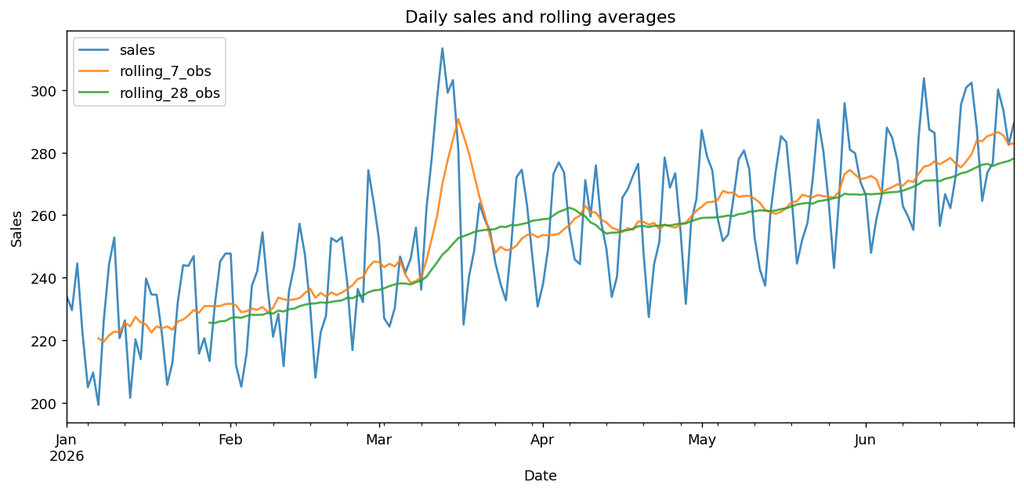

```python
ax = smooth[["sales", "rolling_7_obs", "rolling_28_obs"]].plot(
    figsize=(12, 5), title="Daily sales and rolling averages", alpha=0.85
)
ax.set_ylabel("Sales")
ax.set_xlabel("Date")
plt.show()
```

An observation-based window (`window=7`) means seven rows. A time-based window (`window="7D"`) means observations falling within seven calendar days. They differ when timestamps are irregular.

```python
irregular_example = ts_sales[["sales"]].drop(ts_sales.index[[2, 3, 10]]).head(12).copy()
irregular_example["mean_last_3_rows"] = irregular_example["sales"].rolling(3).mean()
irregular_example["mean_last_3_days"] = irregular_example["sales"].rolling("3D").mean()
irregular_example
```

| date | sales | mean_last_3_rows | mean_last_3_days |
| --- | --- | --- | --- |
| 2026-01-01 | 234.07 | NaN | 234.07 |
| 2026-01-02 | 229.63 | NaN | 231.85 |
| 2026-01-05 | 204.96 | 222.89 | 204.96 |
| 2026-01-06 | 209.63 | 214.74 | 207.30 |
| 2026-01-07 | 199.31 | 204.63 | 204.63 |
| 2026-01-08 | 226.15 | 211.70 | 211.70 |
| 2026-01-09 | 244.23 | 223.23 | 223.23 |
| 2026-01-10 | 252.84 | 241.07 | 241.07 |
| 2026-01-12 | 226.34 | 241.14 | 239.59 |
| 2026-01-13 | 201.56 | 226.91 | 213.95 |
| 2026-01-14 | 220.28 | 216.06 | 216.06 |
| 2026-01-15 | 213.94 | 211.93 | 211.93 |

## 1.13 11. `asfreq()` versus `resample()`

Both operations change frequency, but they answer different questions. `asfreq()` aligns observations to a new grid without summarizing them. `resample()` creates time bins and applies an aggregation. Confusing them can change the meaning of the data.

These methods answer different questions:

- `asfreq()` conforms data to a new time grid; it does not aggregate.
- `resample()` groups observations into time bins and then applies an aggregation or transformation.

```python
weekly_sales = ts_sales["sales"].resample("W-SUN").sum()
monthly_sales = ts_sales["sales"].resample("MS").sum()
monthly_average = ts_sales["sales"].resample("MS").mean()

display(weekly_sales.head())
display(pd.DataFrame({"monthly_total": monthly_sales, "daily_average": monthly_average}))
```

| date | sales |
| --- | --- |
| 2026-01-04 | 930.34 |
| 2026-01-11 | 1557.78 |
| 2026-01-18 | 1570.99 |
| 2026-01-25 | 1607.62 |
| 2026-02-01 | 1621.69 |

| date | monthly_total | daily_average |
| --- | --- | --- |
| 2026-01-01 | 7040.72 | 227.12 |
| 2026-02-01 | 6605.35 | 235.91 |
| 2026-03-01 | 7939.84 | 256.12 |
| 2026-04-01 | 7728.26 | 257.61 |
| 2026-05-01 | 8302.50 | 267.82 |
| 2026-06-01 | 8053.86 | 277.72 |

```python
# Upsampling monthly totals creates empty daily positions.
daily_grid = monthly_sales.asfreq("D")

upsampling = pd.DataFrame({
    "original_positions": daily_grid,
    "forward_fill": daily_grid.ffill(),
    "linear_interpolation": daily_grid.interpolate(method="time")
})
upsampling.head(12)
```

| date | original_positions | forward_fill | linear_interpolation |
| --- | --- | --- | --- |
| 2026-01-01 | 7040.72 | 7040.72 | 7040.72 |
| 2026-01-02 | NaN | 7040.72 | 7026.68 |
| 2026-01-03 | NaN | 7040.72 | 7012.63 |
| 2026-01-04 | NaN | 7040.72 | 6998.59 |
| 2026-01-05 | NaN | 7040.72 | 6984.54 |
| 2026-01-06 | NaN | 7040.72 | 6970.50 |
| 2026-01-07 | NaN | 7040.72 | 6956.45 |
| 2026-01-08 | NaN | 7040.72 | 6942.41 |
| 2026-01-09 | NaN | 7040.72 | 6928.37 |
| 2026-01-10 | NaN | 7040.72 | 6914.32 |
| 2026-01-11 | NaN | 7040.72 | 6900.28 |
| 2026-01-12 | NaN | 7040.72 | 6886.23 |

Forward filling or interpolation creates assumed values—it does not recover observations. The appropriate method depends on what the variable represents. Interpolating inventory levels may be defensible; interpolating individual transaction counts often is not.

### 1.13.1 Bin labels and closed boundaries

> **Interpretation:** every resampled value has two design choices: which observations enter the bin, and which timestamp labels the result. Verify both choices when reporting periods have contractual or accounting meaning.

```python
hourly_demo = pd.Series(
    [10, 20, 30, 40],
    index=pd.to_datetime(["2026-01-01 00:00", "2026-01-01 06:00", "2026-01-01 12:00", "2026-01-01 18:00"])
)

print("Left-labeled daily total:")
display(hourly_demo.resample("D", label="left", closed="left").sum())
```

```
Left-labeled daily total:
```

|  | 0 |
| --- | --- |
| 2026-01-01 | 100 |

For financial, operational, or contractual reporting, explicitly verify which endpoint belongs to each bin and which timestamp labels the result.

### 1.13.2 Multiple aggregations and OHLC summaries

```python
weekly_business_summary = ts_sales.resample("W-SUN").agg({
    "sales": ["sum", "mean", "min", "max"],
    "ad_spend": "sum",
    "promotion": "sum"
})
weekly_business_summary.head()
```

| date | sales sum | sales mean | sales min | sales max | ad_spend sum | promotion sum |
| --- | --- | --- | --- | --- | --- | --- |
| 2026-01-04 | 930.34 | 232.58 | 222.07 | 244.57 | 4870.59 | 0 |
| 2026-01-11 | 1557.78 | 222.54 | 199.31 | 252.84 | 7941.44 | 0 |
| 2026-01-18 | 1570.99 | 224.43 | 201.56 | 239.71 | 9228.80 | 0 |
| 2026-01-25 | 1607.62 | 229.66 | 205.76 | 246.91 | 8107.45 | 0 |
| 2026-02-01 | 1621.69 | 231.67 | 213.36 | 247.70 | 9168.09 | 0 |

```python
# Open-high-low-close summarizes the first, maximum, minimum, and last value in each bin.
weekly_ohlc = ts_sales["sales"].resample("W-SUN").ohlc()
weekly_ohlc.head()
```

| date | open | high | low | close |
| --- | --- | --- | --- | --- |
| 2026-01-04 | 234.07 | 244.57 | 222.07 | 222.07 |
| 2026-01-11 | 204.96 | 252.84 | 199.31 | 220.66 |
| 2026-01-18 | 226.34 | 239.71 | 201.56 | 234.50 |
| 2026-01-25 | 222.01 | 246.91 | 205.76 | 246.91 |
| 2026-02-01 | 215.72 | 247.70 | 213.36 | 247.70 |

OHLC is common in finance but can summarize any ordered measurement when first, highest, lowest, and last values are meaningful.

### 1.13.3 Illustration: daily observations and weekly time bins

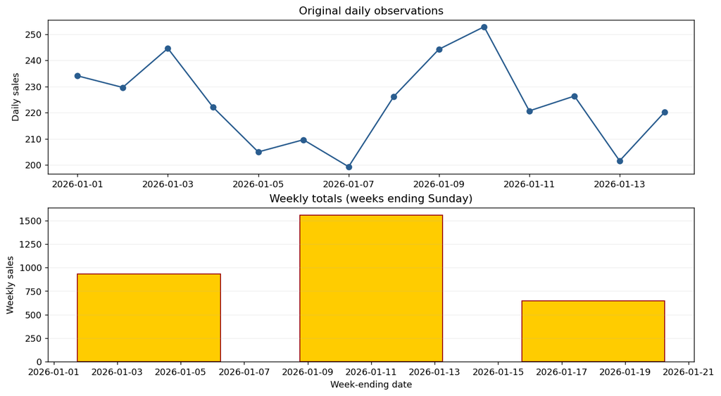

```python
two_weeks = ts_sales["sales"].iloc[:14]
weekly_two_weeks = two_weeks.resample("W-SUN").sum()

fig, axes = plt.subplots(2, 1, figsize=(11, 6), constrained_layout=True)
axes[0].plot(two_weeks.index, two_weeks, marker="o", color="#2A5D8F")
axes[0].set(title="Original daily observations", ylabel="Daily sales")
axes[1].bar(weekly_two_weeks.index, weekly_two_weeks, width=4.5, color="#FFCC00", edgecolor="#990000")
axes[1].set(title="Weekly totals (weeks ending Sunday)", ylabel="Weekly sales", xlabel="Week-ending date")
for ax in axes:
    ax.grid(axis="y", alpha=.2)
plt.show()
```

The lower chart contains newly calculated weekly summaries. It is not merely the same daily series displayed with fewer labels—that distinction is the essence of resampling.

## 1.14 12. Missing timestamps versus missing values

Two different problems can look similar: a timestamp may be absent entirely, or the timestamp may exist while its value is missing. The first requires comparison with an expected calendar; the second is visible through `isna()`. Preserve this distinction before filling anything.

```python
quality = ts_sales[["sales"]].iloc[:20].copy()
quality = quality.drop(quality.index[[4, 11]])       # timestamps absent entirely
quality.loc[quality.index[7], "sales"] = np.nan     # timestamp exists, value absent

print("Missing values in existing rows:", quality["sales"].isna().sum())
print("Rows currently present:", len(quality))

expected_index = pd.date_range(quality.index.min(), quality.index.max(), freq="D")
missing_timestamps = expected_index.difference(quality.index)
print("Missing timestamps:", missing_timestamps.tolist())
```

```
Missing values in existing rows: 1
Rows currently present: 18
Missing timestamps: [Timestamp('2026-01-05 00:00:00'), Timestamp('2026-01-12 00:00:00')]
```

```python
complete_grid = quality.reindex(expected_index)
complete_grid.index.name = "date"
complete_grid["was_missing"] = complete_grid["sales"].isna()

display(complete_grid)
```

| date | sales | was_missing |
| --- | --- | --- |
| 2026-01-01 | 234.07 | False |
| 2026-01-02 | 229.63 | False |
| 2026-01-03 | 244.57 | False |
| 2026-01-04 | 222.07 | False |
| 2026-01-05 | NaN | True |
| 2026-01-06 | 209.63 | False |
| 2026-01-07 | 199.31 | False |
| 2026-01-08 | 226.15 | False |
| 2026-01-09 | NaN | True |
| 2026-01-10 | 252.84 | False |
| 2026-01-11 | 220.66 | False |
| 2026-01-12 | NaN | True |
| 2026-01-13 | 201.56 | False |
| 2026-01-14 | 220.28 | False |
| 2026-01-15 | 213.94 | False |
| 2026-01-16 | 239.71 | False |
| 2026-01-17 | 234.66 | False |
| 2026-01-18 | 234.50 | False |
| 2026-01-19 | 222.01 | False |
| 2026-01-20 | 205.76 | False |

After reindexing, both originally missing values and newly inserted timestamps appear as `NaN`. Create provenance flags before filling if the distinction matters.

```python
filled = complete_grid.copy()
filled["sales_ffill"] = filled["sales"].ffill()
filled["sales_bfill"] = filled["sales"].bfill()
filled["sales_interpolated"] = filled["sales"].interpolate(method="time")
filled.loc[filled["was_missing"]]
```

| date | sales | was_missing | sales_ffill | sales_bfill | sales_interpolated |
| --- | --- | --- | --- | --- | --- |
| 2026-01-05 | NaN | True | 222.07 | 209.63 | 215.85 |
| 2026-01-09 | NaN | True | 226.15 | 252.84 | 239.50 |
| 2026-01-12 | NaN | True | 220.66 | 201.56 | 211.11 |

### 1.14.1 Illustration: distinguish absent rows from `NaN` values

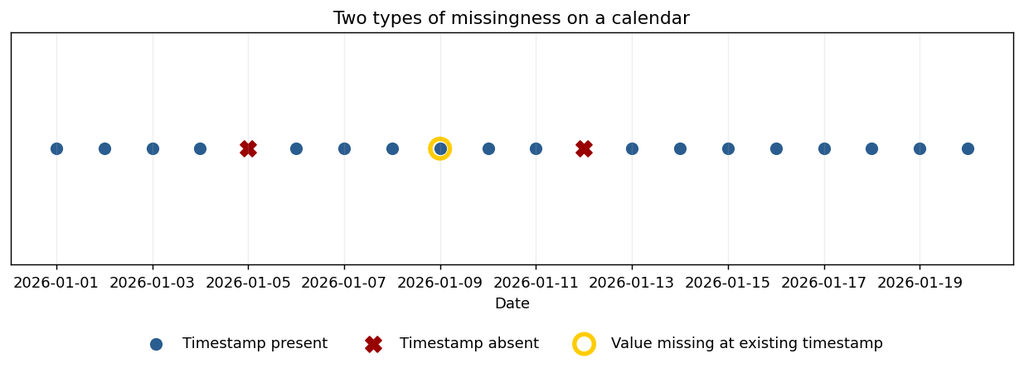

```python
observed_dates = quality.index
full_dates = pd.date_range(quality.index.min(), quality.index.max(), freq="D")
missing_rows = full_dates.difference(observed_dates)
missing_values = quality.index[quality["sales"].isna()]

fig, ax = plt.subplots(figsize=(12, 2.8))
ax.scatter(observed_dates, np.zeros(len(observed_dates)), color="#2A5D8F", s=55, label="Timestamp present")
ax.scatter(missing_rows, np.zeros(len(missing_rows)), marker="X", color="#990000", s=110, label="Timestamp absent")
ax.scatter(missing_values, np.zeros(len(missing_values)), facecolors="none", edgecolors="#FFCC00", linewidths=3, s=170, label="Value missing at existing timestamp")
ax.set_yticks([])
ax.set(title="Two types of missingness on a calendar", xlabel="Date")
ax.legend(ncol=3, loc="upper center", bbox_to_anchor=(0.5, -0.25), frameon=False)
ax.grid(axis="x", alpha=.2)
plt.show()
```

An absent row can only be detected by knowing the expected frequency. An existing row with `NaN` can be detected directly with `isna()`. They may require different explanations and different remedies.

## 1.15 13. Duplicate, unordered, and irregular timestamps

Repeated timestamps are not automatically errors. They may represent separate transactions, multiple devices, or genuinely duplicated records. Detect them first, then use the business meaning—not a generic cleaning rule—to decide whether to aggregate, retain, or remove them.

```python
messy = pd.DataFrame({
    "timestamp": pd.to_datetime(["2026-01-03", "2026-01-01", "2026-01-02", "2026-01-02"]),
    "sales": [120, 100, 110, 15]
})

print("Sorted?", messy["timestamp"].is_monotonic_increasing)
print("Duplicate timestamps?", messy["timestamp"].duplicated().any())
display(messy[messy["timestamp"].duplicated(keep=False)])
```

```
Sorted? False
Duplicate timestamps? True
```

|  | timestamp | sales |
| --- | --- | --- |
| 2 | 2026-01-02 | 110 |
| 3 | 2026-01-02 | 15 |

```python
# A business rule is required. Here duplicate rows represent separate transactions,
# so sales are summed by date.
cleaned = (
    messy.groupby("timestamp", as_index=False)["sales"]
    .sum()
    .sort_values("timestamp")
    .set_index("timestamp")
)

print("Inferred frequency:", pd.infer_freq(cleaned.index))
cleaned
```

```
Inferred frequency: D
```

| timestamp | sales |
| --- | --- |
| 2026-01-01 | 100 |
| 2026-01-02 | 125 |
| 2026-01-03 | 120 |

Never delete duplicates automatically without understanding what they mean. They might be duplicate errors, separate transactions at the same time, or measurements from different entities.

## 1.16 14. Combining dates and times from separate columns

```python
parts = pd.DataFrame({
    "year": [2026, 2026, 2026],
    "month": [1, 2, 3],
    "day": [15, 15, 15],
    "hour": [9, 10, 11]
})

parts["timestamp"] = pd.to_datetime(parts[["year", "month", "day", "hour"]])
parts
```

|  | year | month | day | hour | timestamp |
| --- | --- | --- | --- | --- | --- |
| 0 | 2026 | 1 | 15 | 9 | 2026-01-15 09:00:00 |
| 1 | 2026 | 2 | 15 | 10 | 2026-02-15 10:00:00 |
| 2 | 2026 | 3 | 15 | 11 | 2026-03-15 11:00:00 |

### 1.16.1 Combining a date column and a clock-time column

```python
separate = pd.DataFrame({
    "event_date": ["2026-04-01", "2026-04-02"],
    "event_time": ["09:15:30", "17:45:00"]
})

separate["timestamp"] = pd.to_datetime(
    separate["event_date"] + " " + separate["event_time"],
    format="%Y-%m-%d %H:%M:%S"
)
separate
```

|  | event_date | event_time | timestamp |
| --- | --- | --- | --- |
| 0 | 2026-04-01 | 09:15:30 | 2026-04-01 09:15:30 |
| 1 | 2026-04-02 | 17:45:00 | 2026-04-02 17:45:00 |

### 1.16.2 Extracting clock-time components and elapsed time

```python
events_demo = pd.DataFrame({
    "started": pd.to_datetime(["2026-04-01 09:10", "2026-04-01 13:00"]),
    "finished": pd.to_datetime(["2026-04-01 10:25", "2026-04-01 15:45"])
})
events_demo["hour"] = events_demo["started"].dt.hour
events_demo["minute"] = events_demo["started"].dt.minute
events_demo["duration"] = events_demo["finished"] - events_demo["started"]
events_demo["duration_minutes"] = events_demo["duration"].dt.total_seconds() / 60
events_demo
```

|  | started | finished | hour | minute | duration | duration_minutes |
| --- | --- | --- | --- | --- | --- | --- |
| 0 | 2026-04-01 09:10:00 | 2026-04-01 10:25:00 | 9 | 10 | 0 days 01:15:00 | 75.0 |
| 1 | 2026-04-01 13:00:00 | 2026-04-01 15:45:00 | 13 | 0 | 0 days 02:45:00 | 165.0 |

## 1.17 15. Time zones and daylight-saving time

A naive timestamp records a clock reading without identifying where it occurred. An aware timestamp identifies an instant through its time zone. `tz_localize()` interprets a naive clock reading in a zone; `tz_convert()` displays the same instant in another zone.

A **naive** timestamp has no time-zone information. An **aware** timestamp represents time in a specified zone.

- `tz_localize()` attaches/interprets a time zone without changing the displayed clock reading.
- `tz_convert()` represents the same instant in another time zone, changing the displayed clock reading.

```python
naive = pd.Timestamp("2026-08-27 09:00")
los_angeles = naive.tz_localize("America/Los_Angeles")
new_york = los_angeles.tz_convert("America/New_York")
utc = los_angeles.tz_convert("UTC")

print("Naive:", naive)
print("Los Angeles:", los_angeles)
print("Same instant in New York:", new_york)
print("Same instant in UTC:", utc)
```

```
Naive: 2026-08-27 09:00:00
Los Angeles: 2026-08-27 09:00:00-07:00
Same instant in New York: 2026-08-27 12:00:00-04:00
Same instant in UTC: 2026-08-27 16:00:00+00:00
```

```python
# A robust pattern for globally collected events:
# parse and store in UTC, then convert for local reporting.
events = pd.Series(["2026-08-27T16:00:00Z", "2026-08-27T17:30:00Z"])
events_utc = pd.to_datetime(events, utc=True)
events_la = events_utc.dt.tz_convert("America/Los_Angeles")

pd.DataFrame({"UTC": events_utc, "Los_Angeles": events_la})
```

|  | UTC | Los_Angeles |
| --- | --- | --- |
| 0 | 2026-08-27 16:00:00+00:00 | 2026-08-27 09:00:00-07:00 |
| 1 | 2026-08-27 17:30:00+00:00 | 2026-08-27 10:30:00-07:00 |

### 1.17.1 Daylight-saving transitions

> **Interpretation:** during spring transition, some local clock readings never occur; during autumn transition, some occur twice. Explicit handling makes the chosen interpretation visible and reproducible.

```python
# In Los Angeles, clocks spring forward in March; 02:30 may not exist.
nonexistent = pd.DatetimeIndex(["2026-03-08 01:30", "2026-03-08 02:30", "2026-03-08 03:30"])
localized_spring = nonexistent.tz_localize(
    "America/Los_Angeles", nonexistent="shift_forward"
)
localized_spring
```

```
DatetimeIndex(['2026-03-08 01:30:00-08:00', '2026-03-08 03:00:00-07:00', '2026-03-08 03:30:00-07:00'], dtype='datetime64[ns, America/Los_Angeles]', freq=None)
```

```python
# In autumn, some clock times occur twice. Explicit flags disambiguate them.
ambiguous_fall = pd.DatetimeIndex(["2026-11-01 01:30", "2026-11-01 01:30"])
localized_fall = ambiguous_fall.tz_localize(
    "America/Los_Angeles", ambiguous=[True, False]
)
localized_fall
```

```
DatetimeIndex(['2026-11-01 01:30:00-07:00', '2026-11-01 01:30:00-08:00'], dtype='datetime64[ns, America/Los_Angeles]', freq=None)
```

Do not remove time zones merely to avoid daylight-saving errors. Decide what the timestamp means, localize explicitly, and test transition dates.

## 1.18 16. Periods and fiscal/calendar reporting

```python
period_demo = ts_sales[["sales"]].copy()
period_demo["month_period"] = period_demo.index.to_period("M")
period_demo["quarter_period"] = period_demo.index.to_period("Q")

period_demo.head()
```

| date | sales | month_period | quarter_period |
| --- | --- | --- | --- |
| 2026-01-01 | 234.07 | 2026-01 | 2026Q1 |
| 2026-01-02 | 229.63 | 2026-01 | 2026Q1 |
| 2026-01-03 | 244.57 | 2026-01 | 2026Q1 |
| 2026-01-04 | 222.07 | 2026-01 | 2026Q1 |
| 2026-01-05 | 204.96 | 2026-01 | 2026Q1 |

```python
quarterly = ts_sales["sales"].groupby(ts_sales.index.to_period("Q")).sum()
print(quarterly)
print("Convert period labels to quarter-end timestamps:")
print(quarterly.to_timestamp(how="end"))
```

```
date
2026Q1    21585.91
2026Q2    24084.62
Freq: Q-DEC, Name: sales, dtype: float64
Convert period labels to quarter-end timestamps:
date
2026-03-31 23:59:59.999999999    21585.91
2026-06-30 23:59:59.999999999    24084.62
Name: sales, dtype: float64
```

## 1.19 17. Offsets: calendar-aware date arithmetic

```python
from pandas.tseries.offsets import BDay, MonthEnd, MonthBegin

invoice_date = pd.Timestamp("2026-01-30")

print("One ordinary day:", invoice_date + pd.Timedelta(days=1))
print("One business day:", invoice_date + BDay(1))
print("Current/next month end:", invoice_date + MonthEnd(1))
print("Next month start:", invoice_date + MonthBegin(1))
```

```
One ordinary day: 2026-01-31 00:00:00
One business day: 2026-02-02 00:00:00
Current/next month end: 2026-01-31 00:00:00
Next month start: 2026-02-01 00:00:00
```

A `Timedelta(days=30)` is a fixed duration. `MonthEnd(1)` is a calendar rule. They are not interchangeable.

## 1.20 18. Business calendars and holidays

The built-in business-day frequency skips weekends but not necessarily holidays. `CustomBusinessDay` can incorporate an explicit holiday list or a calendar.

```python
from pandas.tseries.holiday import USFederalHolidayCalendar

federal_calendar = USFederalHolidayCalendar()
federal_holidays = federal_calendar.holidays("2026-01-01", "2026-12-31")
us_business_day = CustomBusinessDay(calendar=federal_calendar)

print("First five federal holidays:")
display(federal_holidays[:5])
print("Business days around New Year's Day:")
display(pd.date_range("2025-12-29", periods=7, freq=us_business_day))
```

```
First five federal holidays:
Business days around New Year's Day:
```

```
DatetimeIndex(['2026-01-01', '2026-01-19', '2026-02-16', '2026-05-25', '2026-06-19'], dtype='datetime64[ns]', freq=None)
```

```
DatetimeIndex(['2025-12-29', '2025-12-30', '2025-12-31', '2026-01-02', '2026-01-05', '2026-01-06', '2026-01-07'], dtype='datetime64[ns]', freq='C')
```

A federal-business-day calendar is not automatically an exchange, company, or university calendar. Use the calendar that matches the actual process being studied.

## 1.21 19. Joining tables by exact and nearest time

Exact timestamp matches are often unavailable: an order may occur between price updates or an event between sensor readings. `merge_asof()` performs an ordered nearest-time join, while `direction` and `tolerance` define which match is acceptable.

```python
orders = pd.DataFrame({
    "order_time": pd.to_datetime(["2026-01-02 09:05", "2026-01-02 10:20", "2026-01-02 11:50"]),
    "revenue": [125, 80, 210]
}).sort_values("order_time")

rates = pd.DataFrame({
    "rate_time": pd.to_datetime(["2026-01-02 09:00", "2026-01-02 10:00", "2026-01-02 11:00"]),
    "conversion_rate": [1.10, 1.11, 1.09]
}).sort_values("rate_time")

matched = pd.merge_asof(
    orders,
    rates,
    left_on="order_time",
    right_on="rate_time",
    direction="backward",
    tolerance=pd.Timedelta("1h")
)
matched
```

|  | order_time | revenue | rate_time | conversion_rate |
| --- | --- | --- | --- | --- |
| 0 | 2026-01-02 09:05:00 | 125 | 2026-01-02 09:00:00 | 1.10 |
| 1 | 2026-01-02 10:20:00 | 80 | 2026-01-02 10:00:00 | 1.11 |
| 2 | 2026-01-02 11:50:00 | 210 | 2026-01-02 11:00:00 | 1.09 |

`merge_asof()` is useful when exact timestamps do not match. Sorting is required. Direction and tolerance should reflect the business question and prevent accidental look-ahead.

## 1.22 20. Importing and exporting dates and times

Importing is often the most difficult part of working with time. Real files contain mixed layouts, ambiguous day/month order, extra spaces, time-zone suffixes, Excel serials, Unix epochs, blanks, and impossible dates. A reliable workflow preserves the original values, parses deliberately, and reports failures.

Imported dates are often the hardest part of the workflow. Common problems include mixed layouts, ambiguous day/month order, Excel serial numbers, Unix epochs, separate date and time columns, time-zone suffixes, inconsistent precision, blanks, and impossible dates.

```python
mixed_import = pd.Series([
    "2026-03-15",
    "03/16/2026",
    "March 17, 2026 2:30 PM",
    "2026-03-18T14:30:00-07:00",
    "",
    "2026-02-30"
], name="raw_timestamp")

parsed_mixed = pd.to_datetime(mixed_import, format="mixed", errors="coerce", utc=True)
import_check = pd.DataFrame({
    "raw": mixed_import,
    "parsed_utc": parsed_mixed,
    "parse_failed": parsed_mixed.isna() & mixed_import.ne("")
})
import_check
```

|  | raw | parsed_utc | parse_failed |
| --- | --- | --- | --- |
| 0 | 2026-03-15 | 2026-03-15 00:00:00+00:00 | False |
| 1 | 03/16/2026 | 2026-03-16 00:00:00+00:00 | False |
| 2 | March 17, 2026 2:30 PM | 2026-03-17 14:30:00+00:00 | False |
| 3 | 2026-03-18T14:30:00-07:00 | 2026-03-18 21:30:00+00:00 | False |
| 4 |  | NaT | False |
| 5 | 2026-02-30 | NaT | True |

`format="mixed"` is useful when each row may follow a different layout, but it does not remove ambiguity. Whenever the source has a documented format, supply that exact format instead.

```python
# Unix epochs: the same integer has a very different meaning depending on its unit.
epoch_seconds = pd.Series([1767225600, 1767312000])
epoch_milliseconds = epoch_seconds * 1000

display(pd.to_datetime(epoch_seconds, unit="s", utc=True))
display(pd.to_datetime(epoch_milliseconds, unit="ms", utc=True))
```

|  | 0 |
| --- | --- |
| 0 | 2026-01-01 00:00:00+00:00 |
| 1 | 2026-01-02 00:00:00+00:00 |

|  | 0 |
| --- | --- |
| 0 | 2026-01-01 00:00:00+00:00 |
| 1 | 2026-01-02 00:00:00+00:00 |

```python
# Excel commonly stores dates as day counts beginning near 1899-12-30.
excel_serials = pd.Series([46023, 46024.5])
excel_dates = pd.to_datetime(excel_serials, unit="D", origin="1899-12-30")
pd.DataFrame({"excel_serial": excel_serials, "parsed": excel_dates})
```

|  | excel_serial | parsed |
| --- | --- | --- |
| 0 | 46023.0 | 2026-01-01 00:00:00 |
| 1 | 46024.5 | 2026-01-02 12:00:00 |

Excel's historical date-system conventions require care, especially when files originate on different systems. Confirm the workbook's date system rather than assuming every serial uses the same origin.

```python
# Normalize text before parsing when imports contain stray spaces or inconsistent separators.
dirty_text = pd.Series([" 2026/04/01 ", "2026.04.02", "2026-04-03"])
normalized_text = dirty_text.str.strip().str.replace(".", "-", regex=False).str.replace("/", "-", regex=False)

pd.DataFrame({
    "raw": dirty_text,
    "normalized": normalized_text,
    "parsed": pd.to_datetime(normalized_text, format="%Y-%m-%d", errors="coerce")
})
```

|  | raw | normalized | parsed |
| --- | --- | --- | --- |
| 0 | 2026/04/01 | 2026-04-01 | 2026-04-01 |
| 1 | 2026.04.02 | 2026-04-02 | 2026-04-02 |
| 2 | 2026-04-03 | 2026-04-03 | 2026-04-03 |

### 1.22.1 A disciplined import pattern

1. Preserve the original text column.
2. Normalize only documented inconsistencies.
3. Parse with an explicit format whenever possible.
4. Use `errors="coerce"` to expose failures as `NaT`.
5. Inspect and report failed rows rather than silently dropping them.
6. Confirm time zones, frequency, minimum/maximum dates, ordering, and duplicates.

> **Principle:** never overwrite the only copy of an imported timestamp. Retaining the original text makes incorrect parsing detectable and reversible.

```python
from io import StringIO

csv_text = """date,sales
2026-01-01,120
2026-01-02,135
2026-01-03,128
"""

from_csv = pd.read_csv(StringIO(csv_text), parse_dates=["date"])
print(from_csv.dtypes)
from_csv
```

```
date     datetime64[ns]
sales             int64
dtype: object
```

|  | date | sales |
| --- | --- | --- |
| 0 | 2026-01-01 | 120 |
| 1 | 2026-01-02 | 135 |
| 2 | 2026-01-03 | 128 |

```python
# Typical file patterns (shown but not executed):
# df = pd.read_csv("sales.csv", parse_dates=["date"])
# df.to_csv("clean_sales.csv", index=False, date_format="%Y-%m-%d")
# df = pd.read_excel("sales.xlsx", parse_dates=["date"])
# df.to_parquet("sales.parquet", index=False)
```

CSV stores dates as text, so parsing rules matter. Parquet preserves data types more reliably. Excel dates can also contain mixed types or time-zone limitations; inspect the result after import.

## 1.23 21. Plotting and formatting date axes

pandas uses Matplotlib for plotting. Matplotlib date locators choose tick positions, and formatters control how dates appear.

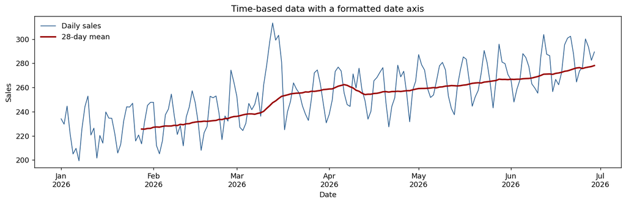

```python
import matplotlib.dates as mdates

fig, ax = plt.subplots(figsize=(12, 4))
ax.plot(ts_sales.index, ts_sales["sales"], color="#2A5D8F", linewidth=1, label="Daily sales")
ax.plot(smooth.index, smooth["rolling_28_obs"], color="#990000", linewidth=2, label="28-day mean")
ax.xaxis.set_major_locator(mdates.MonthLocator())
ax.xaxis.set_major_formatter(mdates.DateFormatter("%b\n%Y"))
ax.set(title="Time-based data with a formatted date axis", xlabel="Date", ylabel="Sales")
ax.legend(frameon=False)
plt.tight_layout()
plt.show()
```

Choose tick spacing and label detail appropriate to the time span. Hourly data may need hour labels; multi-year data usually need months or years.

## 1.24 22. A reusable date/time audit function

```python
def audit_time_series(df, time_col, value_cols=None, expected_freq=None):
    """Return a compact set of checks before time-series analysis."""
    value_cols = value_cols or []
    timestamps = pd.to_datetime(df[time_col], errors="coerce")
    valid = timestamps.dropna().sort_values()

    report = {
        "rows": len(df),
        "unparseable_timestamps": int(timestamps.isna().sum()),
        "duplicate_timestamps": int(timestamps.duplicated(keep=False).sum()),
        "chronologically_sorted": bool(timestamps.is_monotonic_increasing),
        "start": valid.min() if len(valid) else pd.NaT,
        "end": valid.max() if len(valid) else pd.NaT,
        "inferred_frequency": pd.infer_freq(valid.drop_duplicates()) if len(valid.drop_duplicates()) >= 3 else None,
    }

    for col in value_cols:
        report[f"missing_{col}"] = int(df[col].isna().sum())

    if expected_freq and len(valid):
        expected = pd.date_range(valid.min(), valid.max(), freq=expected_freq)
        report["missing_expected_timestamps"] = int(len(expected.difference(valid)))

    return pd.Series(report, name="audit")

audit_time_series(sales, "date", value_cols=["sales", "ad_spend"], expected_freq="D")
```

|  | audit |
| --- | --- |
| rows | 180 |
| unparseable_timestamps | 0 |
| duplicate_timestamps | 0 |
| chronologically_sorted | True |
| start | 2026-01-01 00:00:00 |
| end | 2026-06-29 00:00:00 |
| inferred_frequency | D |
| missing_sales | 0 |
| missing_ad_spend | 0 |
| missing_expected_timestamps | 0 |

## 1.25 23. End-to-end date/time preparation workflow

```python
raw = pd.DataFrame({
    "date": ["2026-01-03", "2026-01-01", "bad date", "2026-01-02", "2026-01-02", "2026-01-05"],
    "sales": [130, 100, 999, 110, 15, 150]
})
raw
```

|  | date | sales |
| --- | --- | --- |
| 0 | 2026-01-03 | 130 |
| 1 | 2026-01-01 | 100 |
| 2 | bad date | 999 |
| 3 | 2026-01-02 | 110 |
| 4 | 2026-01-02 | 15 |
| 5 | 2026-01-05 | 150 |

```python
# 1. Parse explicitly and identify failures.
prepared = raw.copy()
prepared["date"] = pd.to_datetime(prepared["date"], format="%Y-%m-%d", errors="coerce")
rejected = prepared[prepared["date"].isna()].copy()
prepared = prepared.dropna(subset=["date"])

# 2. Aggregate same-day transactions and sort.
prepared = prepared.groupby("date", as_index=False)["sales"].sum().sort_values("date")

# 3. Reindex to the expected daily grid.
prepared = prepared.set_index("date").asfreq("D")
prepared["observed"] = prepared["sales"].notna()

# 4. Add features without overwriting the original variable.
prepared["sales_interpolated"] = prepared["sales"].interpolate(method="time")
prepared["lag_1"] = prepared["sales_interpolated"].shift(1)
prepared["change_1"] = prepared["sales_interpolated"].diff()
prepared["day_name"] = prepared.index.day_name()

print("Rejected records:")
display(rejected)
print("Prepared series:")
display(prepared)
```

```
Rejected records:
Prepared series:
```

|  | date | sales |
| --- | --- | --- |
| 2 | NaT | 999 |

| date | sales | observed | sales_interpolated | lag_1 | change_1 | day_name |
| --- | --- | --- | --- | --- | --- | --- |
| 2026-01-01 | 100.0 | True | 100.0 | NaN | NaN | Thursday |
| 2026-01-02 | 125.0 | True | 125.0 | 100.0 | 25.0 | Friday |
| 2026-01-03 | 130.0 | True | 130.0 | 125.0 | 5.0 | Saturday |
| 2026-01-04 | NaN | False | 140.0 | 130.0 | 10.0 | Sunday |
| 2026-01-05 | 150.0 | True | 150.0 | 140.0 | 10.0 | Monday |

A good workflow preserves evidence: rejected records are retained, the observed/interpolated distinction is explicit, and the raw value is not silently overwritten.

## 1.26 24. Common mistakes and safer alternatives

| Mistake | Why it causes trouble | Safer practice |
| --- | --- | --- |
| Keeping dates as strings | Incorrect sorting and no time operations | Parse early and inspect dtype |
| Trusting automatic parsing | Ambiguous dates may parse incorrectly | Specify a known format |
| Forgetting to sort | Lags and rolling windows may use the wrong order | Sort and assert monotonicity |
| Treating missing rows as missing values | Entire time periods can disappear unnoticed | Compare with an expected index |
| Using `shift(7)` on irregular data | Seven rows may not mean seven days | Regularize first or use time-aware logic |
| Confusing `asfreq` and `resample` | Can create wrong summaries | Decide whether you need alignment or aggregation |
| Filling missing values silently | Invented values appear observed | Preserve a missingness/provenance flag |
| Dropping duplicate timestamps blindly | May discard legitimate transactions | Investigate and apply a business rule |
| Mixing naive and aware timestamps | Comparisons and merges fail or misalign | Standardize zones, often to UTC |
| Ignoring DST | Some local times repeat or do not exist | Localize explicitly and test transitions |
| Using future data in features | Produces unintended use of later information and misleading results | Ensure features were available at prediction time |

### 1.26.1 Useful assertions

```python
assert isinstance(ts_sales.index, pd.DatetimeIndex)
assert ts_sales.index.is_monotonic_increasing
assert ts_sales.index.is_unique
assert not ts_sales["sales"].isna().any()
assert pd.infer_freq(ts_sales.index) == "D"

print("All validation checks passed.")
```

```
All validation checks passed.
```

## 1.27 25. Practice exercises

Try these before opening the solutions.

1. Create an hourly `DatetimeIndex` beginning at `2026-09-01 08:00` with 24 observations.
2. Parse `"27-08-2026 18:30"` using an explicit format.
3. From `ts_sales`, select all observations from February 10 through February 20, inclusive.
4. Create a column containing sales from seven observations earlier.
5. Calculate weekly sales totals using weeks ending Sunday.
6. Find any missing calendar dates in the `practice_irregular` series below.
7. Compute a seven-calendar-day rolling mean for `practice_irregular`.
8. Convert `2026-08-27 09:00` in Los Angeles to New York time.
9. Explain why interpolated sales should not silently replace original sales.
10. Using `merge_asof`, match each order to the most recent earlier rate.
11. Parse Excel serial `46024.5` using the documented Excel origin.
12. Create sine and cosine features for an hour-of-day column.
13. Select only observations occurring between 9:00 AM and 5:00 PM.
14. Explain why a missing timestamp and a timestamp with a missing value are different data-quality problems.

```python
practice_irregular = ts_sales[["sales"]].iloc[:15].drop(ts_sales.index[[3, 8, 9]])
practice_irregular
```

| date | sales |
| --- | --- |
| 2026-01-01 | 234.07 |
| 2026-01-02 | 229.63 |
| 2026-01-03 | 244.57 |
| 2026-01-05 | 204.96 |
| 2026-01-06 | 209.63 |
| 2026-01-07 | 199.31 |
| 2026-01-08 | 226.15 |
| 2026-01-11 | 220.66 |
| 2026-01-12 | 226.34 |
| 2026-01-13 | 201.56 |
| 2026-01-14 | 220.28 |
| 2026-01-15 | 213.94 |

**Click to reveal solutions**

The executable solution cells follow immediately below. Attempt the exercises first.

```python
# 1
answer_1 = pd.date_range("2026-09-01 08:00", periods=24, freq="h")
answer_1
```

```
DatetimeIndex(['2026-09-01 08:00:00', '2026-09-01 09:00:00', '2026-09-01 10:00:00', '2026-09-01 11:00:00',
               '2026-09-01 12:00:00', '2026-09-01 13:00:00', '2026-09-01 14:00:00', '2026-09-01 15:00:00',
               '2026-09-01 16:00:00', '2026-09-01 17:00:00', '2026-09-01 18:00:00', '2026-09-01 19:00:00',
               '2026-09-01 20:00:00', '2026-09-01 21:00:00', '2026-09-01 22:00:00', '2026-09-01 23:00:00',
               '2026-09-02 00:00:00', '2026-09-02 01:00:00', '2026-09-02 02:00:00', '2026-09-02 03:00:00',
               '2026-09-02 04:00:00', '2026-09-02 05:00:00', '2026-09-02 06:00:00', '2026-09-02 07:00:00'],
              dtype='datetime64[ns]', freq='h')
```

```python
# 2
answer_2 = pd.to_datetime("27-08-2026 18:30", format="%d-%m-%Y %H:%M")
answer_2
```

```
Timestamp('2026-08-27 18:30:00')
```

```python
# 3
answer_3 = ts_sales.loc["2026-02-10":"2026-02-20"]
answer_3[["sales"]]
```

| date | sales |
| --- | --- |
| 2026-02-10 | 228.39 |
| 2026-02-11 | 211.69 |
| 2026-02-12 | 235.58 |
| 2026-02-13 | 243.72 |
| 2026-02-14 | 257.24 |
| 2026-02-15 | 247.58 |
| 2026-02-16 | 231.06 |
| 2026-02-17 | 208.01 |
| 2026-02-18 | 222.55 |
| 2026-02-19 | 227.76 |
| 2026-02-20 | 252.68 |

```python
# 4
answer_4 = ts_sales.assign(sales_lag_7=ts_sales["sales"].shift(7))
answer_4[["sales", "sales_lag_7"]].head(10)
```

| date | sales | sales_lag_7 |
| --- | --- | --- |
| 2026-01-01 | 234.07 | NaN |
| 2026-01-02 | 229.63 | NaN |
| 2026-01-03 | 244.57 | NaN |
| 2026-01-04 | 222.07 | NaN |
| 2026-01-05 | 204.96 | NaN |
| 2026-01-06 | 209.63 | NaN |
| 2026-01-07 | 199.31 | NaN |
| 2026-01-08 | 226.15 | 234.07 |
| 2026-01-09 | 244.23 | 229.63 |
| 2026-01-10 | 252.84 | 244.57 |

```python
# 5
answer_5 = ts_sales["sales"].resample("W-SUN").sum()
answer_5.head()
```

| date | sales |
| --- | --- |
| 2026-01-04 | 930.34 |
| 2026-01-11 | 1557.78 |
| 2026-01-18 | 1570.99 |
| 2026-01-25 | 1607.62 |
| 2026-02-01 | 1621.69 |

```python
# 6
expected = pd.date_range(practice_irregular.index.min(), practice_irregular.index.max(), freq="D")
answer_6 = expected.difference(practice_irregular.index)
answer_6
```

```
DatetimeIndex(['2026-01-04', '2026-01-09', '2026-01-10'], dtype='datetime64[ns]', freq=None)
```

```python
# 7
answer_7 = practice_irregular["sales"].rolling("7D").mean()
answer_7
```

| date | sales |
| --- | --- |
| 2026-01-01 | 234.07 |
| 2026-01-02 | 231.85 |
| 2026-01-03 | 236.09 |
| 2026-01-05 | 228.31 |
| 2026-01-06 | 224.57 |
| 2026-01-07 | 220.36 |
| 2026-01-08 | 219.04 |
| 2026-01-11 | 212.14 |
| 2026-01-12 | 216.42 |
| 2026-01-13 | 214.80 |
| 2026-01-14 | 219.00 |
| 2026-01-15 | 216.56 |

```python
# 8
answer_8 = pd.Timestamp("2026-08-27 09:00").tz_localize("America/Los_Angeles").tz_convert("America/New_York")
answer_8
```

```
Timestamp('2026-08-27 12:00:00-0400', tz='America/New_York')
```

**9.** Interpolation creates estimates based on an assumption. Keeping original and imputed values separate preserves transparency, enables sensitivity analysis, and prevents downstream users from mistaking estimates for observations.

```python
# 10
answer_10 = pd.merge_asof(
    orders.sort_values("order_time"),
    rates.sort_values("rate_time"),
    left_on="order_time",
    right_on="rate_time",
    direction="backward"
)
answer_10
```

|  | order_time | revenue | rate_time | conversion_rate |
| --- | --- | --- | --- | --- |
| 0 | 2026-01-02 09:05:00 | 125 | 2026-01-02 09:00:00 | 1.10 |
| 1 | 2026-01-02 10:20:00 | 80 | 2026-01-02 10:00:00 | 1.11 |
| 2 | 2026-01-02 11:50:00 | 210 | 2026-01-02 11:00:00 | 1.09 |

## 1.28 26. Mini-challenge: prepare complex date/time data

Using the raw data below:

1. Parse the date column and report invalid values.
2. Resolve duplicate dates using a defensible rule.
3. Create a complete daily time grid.
4. Preserve an indicator identifying observed versus missing sales.
5. Choose and document a missing-value treatment.
6. Add lag-1, lag-7, day-of-week, and a 7-day rolling mean.
7. Ensure the rolling feature represents only earlier observations and does not include the current day's value.

The last point is critical: when a feature for day `t` must represent information available before day `t`, shift before rolling. This preserves the intended timing of the feature.

```python
challenge = pd.DataFrame({
    "date": ["2026-04-01", "2026-04-02", "2026-04-04", "2026-04-04", "unknown", "2026-04-07", "2026-04-08"],
    "sales": [90, 95, 110, 8, 500, np.nan, 125]
})
challenge
```

|  | date | sales |
| --- | --- | --- |
| 0 | 2026-04-01 | 90.0 |
| 1 | 2026-04-02 | 95.0 |
| 2 | 2026-04-04 | 110.0 |
| 3 | 2026-04-04 | 8.0 |
| 4 | unknown | 500.0 |
| 5 | 2026-04-07 | NaN |
| 6 | 2026-04-08 | 125.0 |

```python
# One defensible solution (assumption: duplicate rows are separate transactions).
challenge_clean = challenge.copy()
challenge_clean["date"] = pd.to_datetime(challenge_clean["date"], format="%Y-%m-%d", errors="coerce")
challenge_rejected = challenge_clean[challenge_clean["date"].isna()]

challenge_clean = (
    challenge_clean.dropna(subset=["date"])
    .groupby("date", as_index=False, dropna=False)["sales"]
    .sum(min_count=1)
    .set_index("date")
    .sort_index()
    .asfreq("D")
)
challenge_clean["observed_sales"] = challenge_clean["sales"].notna()
challenge_clean["sales_filled"] = challenge_clean["sales"].interpolate(method="time")
challenge_clean["lag_1"] = challenge_clean["sales_filled"].shift(1)
challenge_clean["lag_7"] = challenge_clean["sales_filled"].shift(7)
challenge_clean["day_of_week"] = challenge_clean.index.day_name()
challenge_clean["rolling_7_past_only"] = challenge_clean["sales_filled"].shift(1).rolling(7).mean()

display(challenge_rejected)
display(challenge_clean)
```

|  | date | sales |
| --- | --- | --- |
| 4 | NaT | 500.0 |

| date | sales | observed_sales | sales_filled | lag_1 | lag_7 | day_of_week | rolling_7_past_only |
| --- | --- | --- | --- | --- | --- | --- | --- |
| 2026-04-01 | 90.0 | True | 90.00 | NaN | NaN | Wednesday | NaN |
| 2026-04-02 | 95.0 | True | 95.00 | 90.00 | NaN | Thursday | NaN |
| 2026-04-03 | NaN | False | 106.50 | 95.00 | NaN | Friday | NaN |
| 2026-04-04 | 118.0 | True | 118.00 | 106.50 | NaN | Saturday | NaN |
| 2026-04-05 | NaN | False | 119.75 | 118.00 | NaN | Sunday | NaN |
| 2026-04-06 | NaN | False | 121.50 | 119.75 | NaN | Monday | NaN |
| 2026-04-07 | NaN | False | 123.25 | 121.50 | NaN | Tuesday | NaN |
| 2026-04-08 | 125.0 | True | 125.00 | 123.25 | 90.0 | Wednesday | 110.57 |

## 1.29 27. Quick-reference checklist

Before analyzing any time-based dataset, ask:

- Is the time column truly a datetime dtype?
- What does each timestamp represent: event time, reporting time, start, or end of a period?
- Is the index sorted and unique—or are duplicates meaningful?
- What is the expected frequency? Is the observed series regular?
- Are entire timestamps missing, or only values?
- What time zone is intended? Are DST transitions relevant?
- How were observations aggregated and bins labeled?
- Were imputed values clearly identified?
- Does each lag or rolling feature use the intended historical window?
- Are calendar conventions, business days, and holidays documented?

### 1.29.1 Key functions to remember

`datetime.strptime`, `datetime.strftime`, `dateutil.parser.parse`, `relativedelta`, `np.datetime64`, `np.timedelta64`, `pd.to_datetime`, `pd.date_range`, `pd.bdate_range`, `pd.period_range`, `pd.timedelta_range`, `pd.Timestamp`, `pd.Timedelta`, `pd.Period`, `.dt`, `.set_index`, `.sort_index`, `.loc`, `.shift`, `.diff`, `.pct_change`, `.rolling`, `.expanding`, `.ewm`, `.asfreq`, `.resample`, `.reindex`, `.to_period`, `.tz_localize`, `.tz_convert`, `pd.merge_asof`, and `pd.infer_freq`.

### 1.29.2 Modern pandas frequency aliases

| Meaning | Current alias | Common legacy alias |
| --- | --- | --- |
| Month start / end | `MS` / `ME` | `MS` / `M` |
| Quarter start / end | `QS` / `QE` | `QS` / `Q` |
| Year start / end | `YS` / `YE` | `AS` / `A` |
| Hour | `h` | `H` |
| Minute | `min` | `T` |
| Second | `s` | `S` |

Multipliers combine with aliases: `2W`, `90min`, `3h`. Anchors specify boundaries: `W-MON`, `QE-NOV`, and `YE-MAR`.